Yongsang Park

# 1. Spiders

These are the data on the running speed (cm/s) of a certain species of spider.

```r
spider = c(1.25, 1.64, 1.91, 2.31, 2.37, 2.38, 2.84, 2.87, 2.93, 2.94, 2.98, 3.00, 3.09, 3.22, 3.41)
```

## 1a.

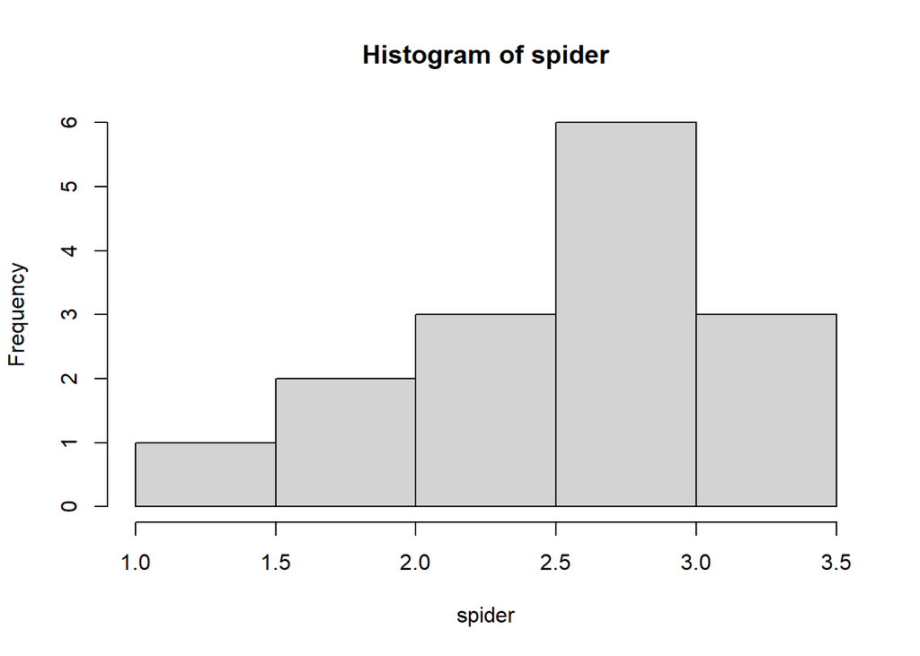

```r
hist(spider)
```

## 1b.

```r
mean(spider)
```

```
## [1] 2.609333
```

```r
sd(spider)
```

```
## [1] 0.6178473
```

The mean indicates the average of the overall numbers. The standard deviation measures how disperse the values are in relation to the mean.

## 1c.

```r
quantile(spider)
```

```
##   0%  25%  50%  75% 100%
## 1.25 2.34 2.87 2.99 3.41
```

I agree. The quartiles look good to me.

## 1d.

```r
IQR(spider)
```

```
## [1] 0.65
```

## 1e.

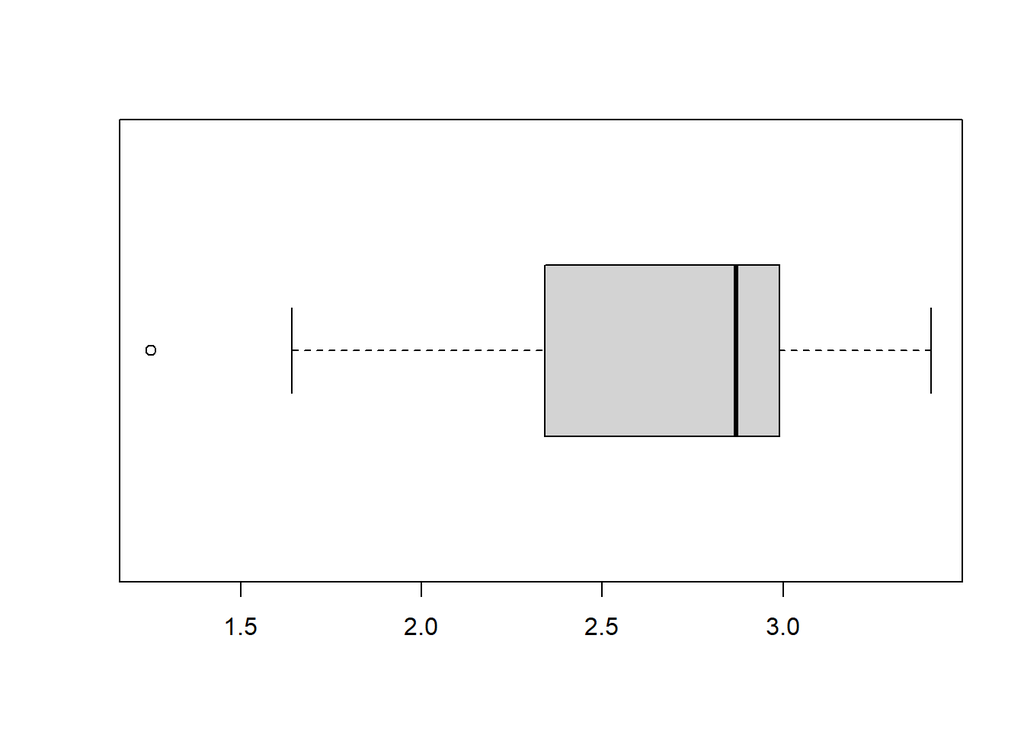

```r
boxplot(spider, horizontal = TRUE)
```

# 2. Two histograms

## 2a.

Histogram A / A starts at 5, but B starts at -40

## 2b.

Histogram B / Because B has a larger range than A.

## 2c.

For finding the mean and the standard deviation, I think the second pair is easy to find them because you can find the data distribution at a glance.

# 3. Circuit board

## 3a.

P(red and green) = red * green (because they are independent)

```r
0.9 * 0.75
```

```
## [1] 0.675
```

67.5%

## 3b.

P(red and not green) + P(not red and green)

```r
0.9 * 0.25 + 0.1 * 0.75
```

```
## [1] 0.3
```

# 4. Fruit flies

The possible combinations to choose two flies are (B stands for black, G stands for gray) (B, B), (B, G), (G, B), (G, G). The combinations that two chosen flies have the same color are (B, B) and (G, G). The possibility for (B, B) is

```r
BB = 0.3 * 0.3
BB
```

```
## [1] 0.09
```

and the possibility for (G, G) is

```r
GG = 0.7 * 0.7
GG
```

```
## [1] 0.49
```

They could be a multiplication because the possibilities are independent. So (B, B) + (G, G) is

```r
BB + GG
```

```
## [1] 0.58
```

# 5. Dice

A is the event that the sum of dice is no more than 4. B is the event that the first die is a 2.

## 5a.

The possible outcomes for A are (1, 1), (1, 2), (1, 3), (2, 1), (2, 2), (3, 1), so P(A) is

```r
A = 6 / 36
A
```

```
## [1] 0.1666667
```

## 5b.

The possible outcomes for B are (2, 1), (2, 2), (2, 3), (2, 4), (2, 5), (2, 6), so P(B) is

```r
B = 6 / 36
B
```

```
## [1] 0.1666667
```

## 5c.

The possible outcome for A and B is (2, 1), (2, 2), so P(A and B) is

```r
AB = 2 / 36
AB
```

```
## [1] 0.05555556
```

## 5d.

P(A and B) =

```r
AB
```

```
## [1] 0.05555556
```

P(A) * P(B) =

```r
A * B
```

```
## [1] 0.02777778
```

Are P(A and B) and P(A) * P(B) equal?

```r
AB == A * B
```

```
## [1] FALSE
```

As they are not equal, they are dependent.

## 5e.

P(A|B) means find the possible A when B happens. The total possible ways that B happens are 6. When B happens, the total possible ways that A happens are 2. So, P(A|B) =

```r
PAB = 2 / 6
PAB
```

```
## [1] 0.3333333
```

## 5f.

Does P(A|B) equal to P(A and B) / P(B)?

```r
PAB == AB / B
```

```
## [1] TRUE
```